# Random sampling models

# Introduccion

The following article presents a series of fitted models for a random sampling scenario. Two types of models will be established:

- Models without zeros: in this first scenario the response variable will be transformed in order to present no zero. Also, two types of response variables will be used:
  - Catches: quantitative and continuous variable, it reflects the weight in tons (biomass) of the target species that has been caught.
  - CPUE: quantitative and continuous variable, reflects the catches per unit of effort, the $CPUE = \frac{Catches}{effort}$, where the effort represents the time that the fishing gear is active (trawling minutes).

  On the other hand, the explanatory variables included in the models will be bathymetry (seabed depth (m)) and effort (time (min) the fishing gear is active), the latter variable will be included in three different ways:
  - As a covariate in the linear predictor
  - As an offset
  - Dividing to catches (CPUE)
- Models with zeros: once the models have been adjusted with the response variable transformed, we proceeded to the adjustment of hurdle models or delta models. For these models, the response variables and the explanatory variables will follow the same scheme as above.

# Model without 0

In this first section, the response variable catches will be transformed in order to eliminate the zeros and obtain the catches per unit of effort (CPUE). Therefore, 0.1 will be added to each of the observation in the study.

```r
# Transform response variable
### Catches
dataset1$abut <- dataset1$abu + 0.1 # add 0.1 to eacho observation
### CPUE
dataset1$CPUE <- dataset1$abu/dataset1$eff
dataset1$CPUEt <- dataset1$abut/dataset1$eff
```

## Descriptive of the response variable

### Figure 1.1

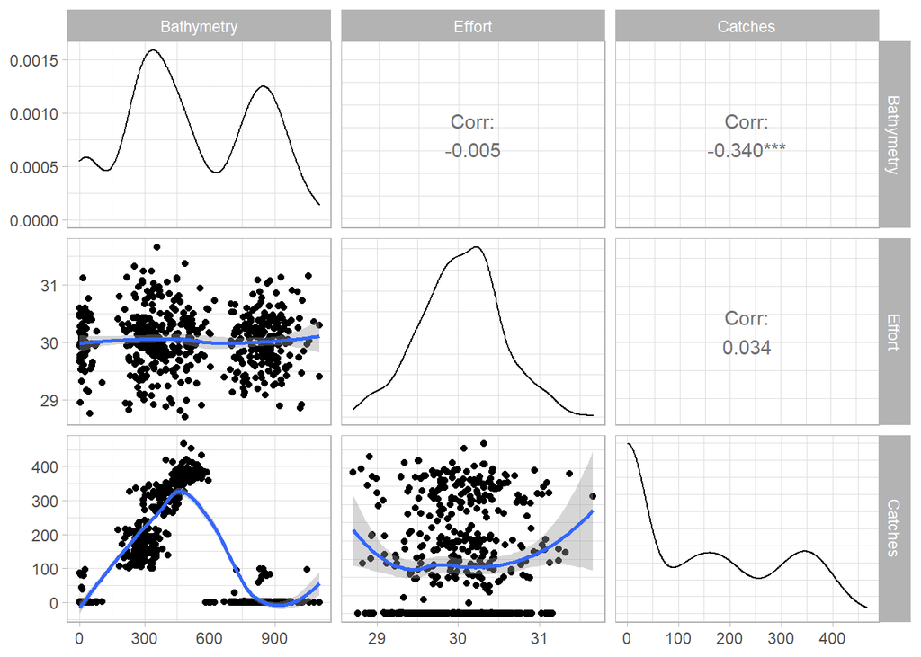

### Figure 1.2

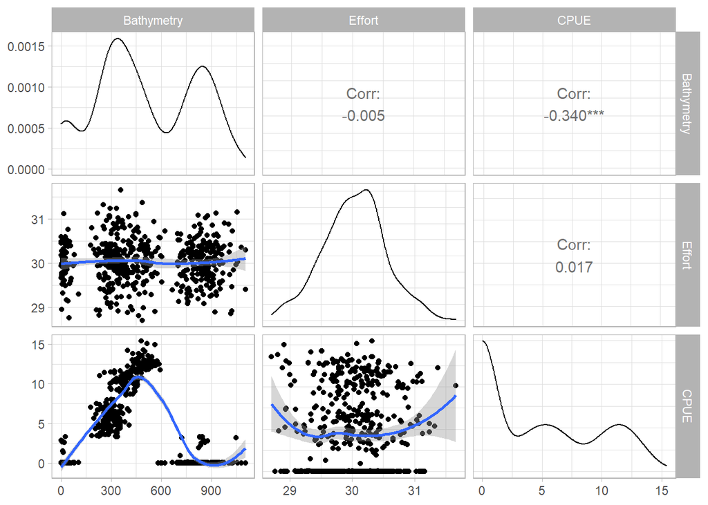

## Result models

All the models have been presented in a complementary document (ANEXO). In order to summarize the information, the following table is presented and the best fitting model is chosen (Table 1).

In line with Table 1, the best model proposed would be number 15, since it has a low DIC and LCPO, 515.15 and 0.5 respectively. However, it has to be checked if the model has a good residual behavior. The formulation of model 15 is as follows:

$$\text{CPUE}(s_{i}) \sim \text{lgnormal} (\mu(s_{i}), \sigma_{i}) \\
\mu(s_{i}) = \beta_{0} + f(B(s_{i})) + u(s_{i}) \\
u(s_{i}) \sim GMRF(0, \Sigma)$$

|  | family | Response | Offset | Spatial | Smoothing | DIC | LCPO |
| --- | --- | --- | --- | --- | --- | --- | --- |
| mod1 | GA | Catches | NO | NO | NO | 4935.85 | 4.61 |
| mod2 | LN | Catches | NO | NO | NO | 5052.16 | 4.72 |
| mod3 | GA | CPUE | NO | NO | NO | 1293.58 | 1.21 |
| mod4 | LG | CPUE | NO | NO | NO | 1410.7 | 1.32 |
| mod5 | GA | Catches | NO | YES | NO | 4563.03 | 46.14 |
| mod6 | LG | Catches | NO | YES | NO | 4594.32 | 4.35 |
| mod7 | GA | CPUE | NO | YES | NO | 934.02 | 45.92 |
| mod8 | LN | CPUE | NO | YES | NO | 953.74 | 0.94 |
| mod9 | GA | Catches | NO | YES | YES rw1 | 4107.59 | 45.53 |
| mod10 | GA | CPUE | NO | YES | YES rw1 | 466.79 | 42.3 |

[output cut: 7 more lines]

## Model validation

In Figure 2, it can be seen that the residuals oscillate between quite high values, which already indicates problems in the model. Likewise, the fitted values versus the residuals and the observed values also present problem of trend and fit. Consequently, it does not seem that a good fit is being obtained.

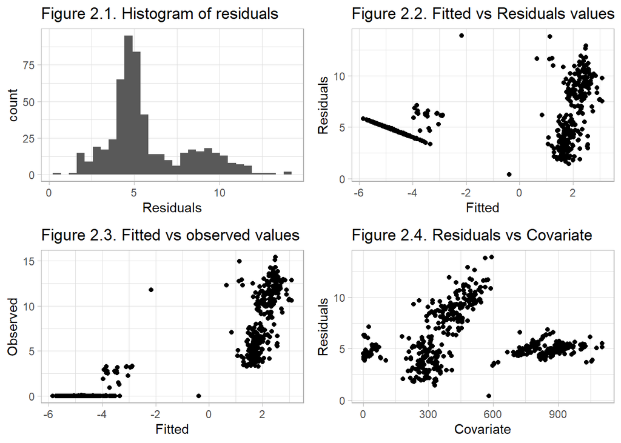

## Output fixed

|  | mean | sd | 0.025quant | 0.5quant | 0.975quant | mode | kld |
| --- | --- | --- | --- | --- | --- | --- | --- |
| Intercept | -1.827705 | 0.1178403 | -2.05959 | -1.828265 | -1.59257 | -1.829196 | 1.08e-05 |

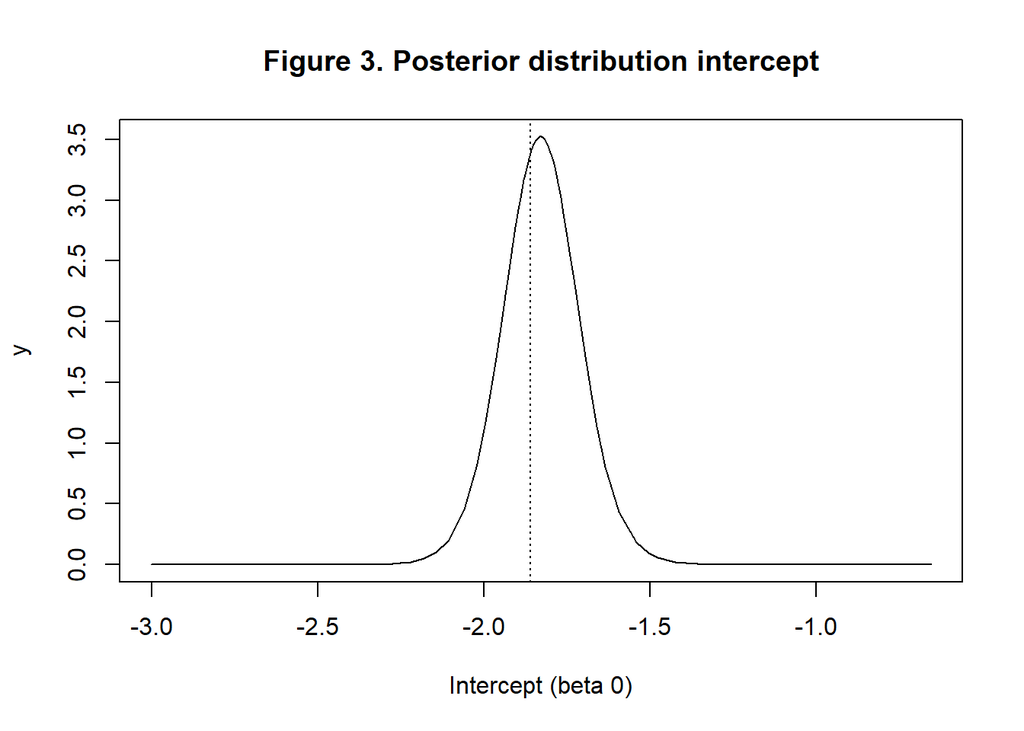

## Output hyperparameters

|  | mean | sd | 0.025quant | 0.5quant | 0.975quant | mode |
| --- | --- | --- | --- | --- | --- | --- |
| Precision for the lognormal observations | 0.6046059 | 0.0518129 | 0.5067247 | 0.6034331 | 0.7103469 | 0.6023488 |
| Precision for inla.group(bath, n = 30) | 25.2291932 | 8.4811046 | 12.3497751 | 23.9972151 | 45.2386307 | 21.6864618 |
| Theta1 for w | -3.8916115 | 0.5075933 | -4.8649683 | -3.9020351 | -2.8706479 | -3.9394722 |
| Theta2 for w | 3.2055315 | 0.3938114 | 2.4205302 | 3.2103379 | 3.9675018 | 3.2275814 |

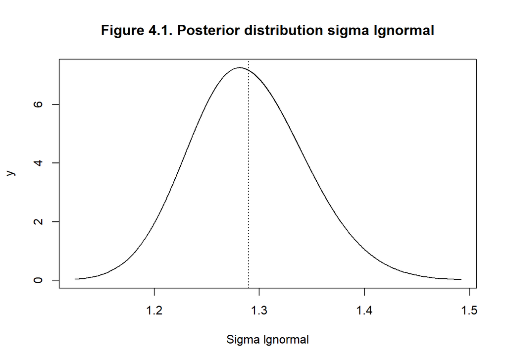

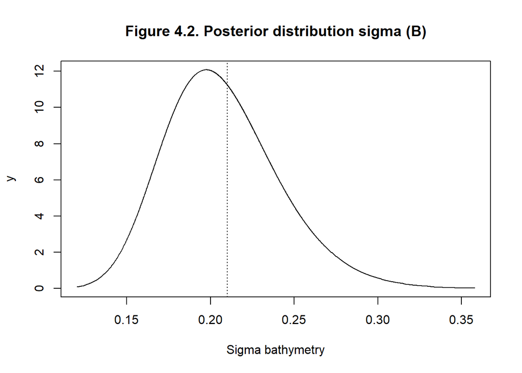

On the other hand, it is also interesting to obtain the hyperparameters related to the spatial term. To estimate the Matérn covariance of the spatial term it is necessary to estimate the Matérn correlation (Figure 5) and the variance of the spatial term.

The Matérn correlation function has an unknown parameter k that is indirectly linked to the distance at which the correlation diminishes. The k of the Matern correlation function and the range r of a variogram are brother and sister. In this case, $k$ has a large value of 26.61, likewise, the mean value of the posterior distribution of sigma is 0.56.

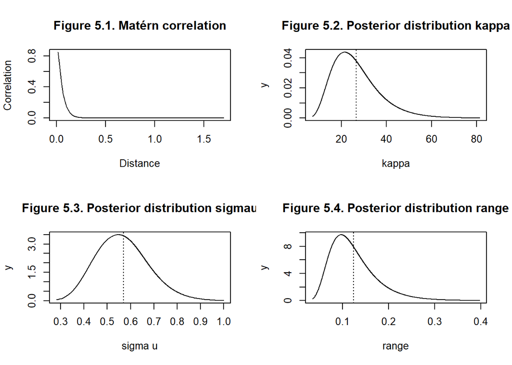

Finally, a heat map (Figure 6) with the distribution of the spatial term is presented. it highlights how the zones with high values of the response variable present a high value in the spatial term.

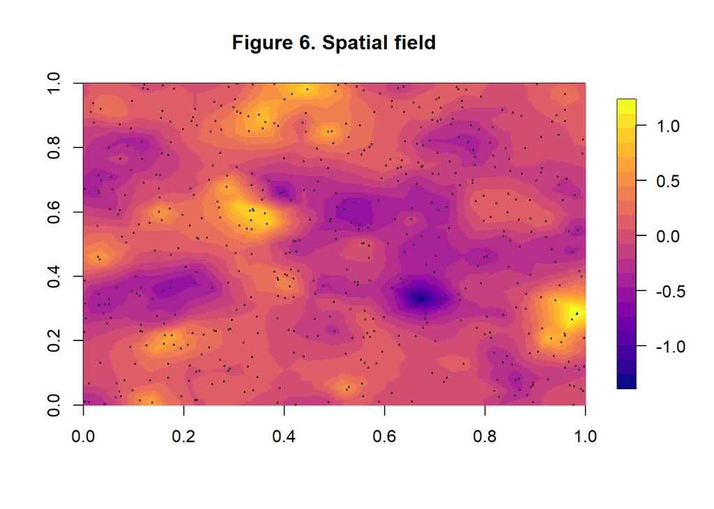

## Output smoothing

For smoothing, a window division of 30 and rw1 (random walk model of order 1) model were used. In Figure 7 it is possible to observe how at low and high bathymetries the values of catchability are low, reaching the maximum of the variable at intermediate bathymetries.

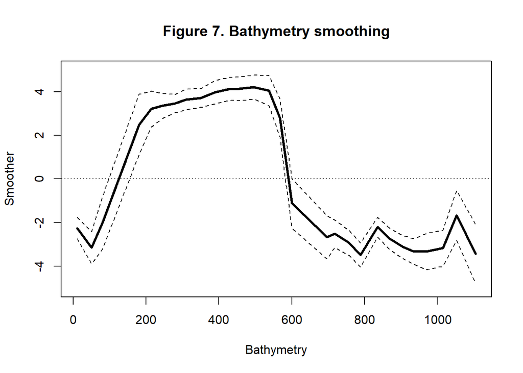

## Discussion

In summary, none of the models seems to represent a good fit, this may be because the response variable has been transformed to avoid zeros. Instead of this methodology we should model the zeros. Therefore, in the next section we apply hurdle or delta models.

# Models with zeros: Hurdle models

The dataset used on a random sampling, simulating an oceanographic campaign, presents more than 30 % of zeros. For this type of situation it is convenient to use a hurdle model. A hurdle model for continuous data consists of a binary part and a continuous part. The distribution for the binary part will again be the Bernoulli distribution, but for the continuous part we could use a gamma or lgnormal distribution. An extended explanation of the models can be found in the supplemental material.

## Descriptive of the response variable

The descriptive data banl follows the same guidelines as in the previous section, except that in this case the response variable (catches and CPUE) have zeros.

### Figure 1.1

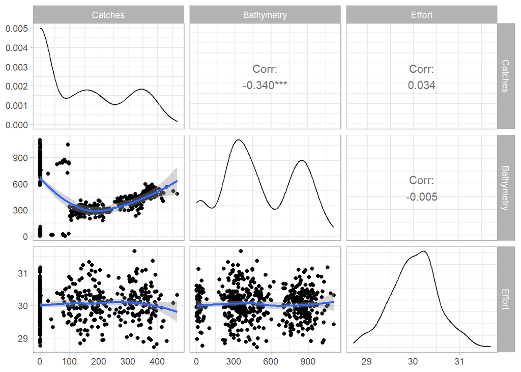

### Figure 1.2

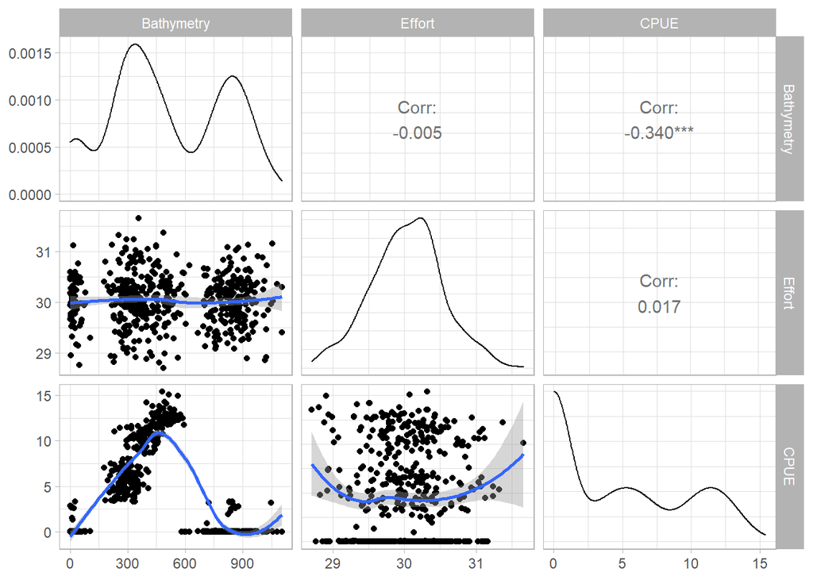

## Result models

$$\text{Y}(s_{i}) \sim \text{Ber}(\pi(s_{i})) \\
\text{Z}(s_{i}) \sim \text{Gamma}(\mu(s_{i}), \phi) \\
logit(\pi(s_{i})) = \beta_{0Y} + f(B(s_{i})) + u(s_{iY}) \\
u(s_{iY}) \sim \text{GMRF}(0, \Sigma) \\
log(\mu(s_{i})) = \beta_{0Z} + f(B(s_{i})) + u_(s_{iZ}) \\
u(s_{iZ}) \sim \text{GMRF}(0, \Sigma)$$

|  | Models | Family | Response | Bathymetry | Spatial term | DIC | LCPO |
| --- | --- | --- | --- | --- | --- | --- | --- |
| modh1 | modh1 | GA | CPUE | rw1 | No share | 2016.86 | 4.21 |
| modh2 | modh2 | GA | CPUE | rw1 | Share | 2066.99 | 3.35 |
| modh3 | modh3 | LN | CPUE | rw1 | Share | 2051.1 | 1.18 |
| modh4 | modh4 | LN | CPUE | rw1 | No share | 2021.05 | 1.17 |
| modh5 | modh5 | GA | Catches | rw1 | No share | 4344.03 | 6.88 |
| modh6 | modh6 | GA | CPUE | poly 2 | No share | 2390.26 | 6.38 |

## Model validation

Figure 8 shows a series of graphs that allow us to evaluate whether the model fit is good or not. The graphs show a great improvement compared to the fit of model 15, however, it appears that there aree still some trend problemas.

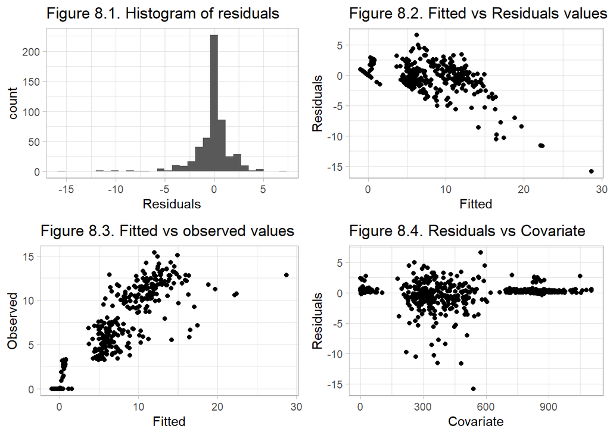

## Output fixed

As in the model of the previous section, there is only one fixed parameter, the intercept. In this case, the confidence interval contains zero so the intercept may be zero. In fact, the probability that the intercept would be zero is 85.71 %.

|  | mean | sd | 0.025quant | 0.5quant | 0.975quant | mode | kld |
| --- | --- | --- | --- | --- | --- | --- | --- |
| Intercept | 0.0266363 | 0.1431005 | -0.2483755 | 0.0242391 | 0.3144534 | 0.0189248 | 5.73e-05 |

```r
# probability of being 0
(sum(modh1$summary.fixed > 0))/length(modh1$summary.fixed)
```

```
## [1] 0.8571429
```

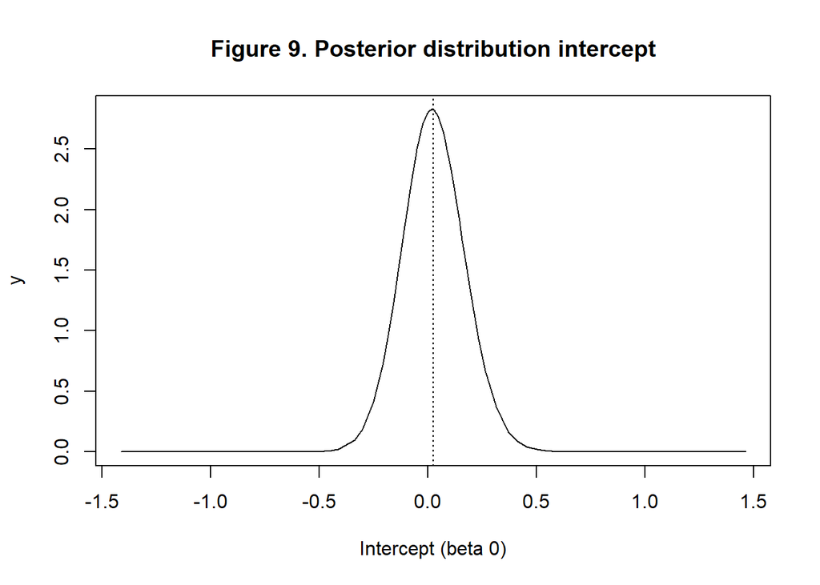

## Output hyperparameters

In the following section the outputs of the posterior distributions for the hyperparameters are presented, likewise, in Figure 10 the posterior distribution with the mean of each of the hyperparameters are shown.

|  | mean | sd | 0.025quant | 0.5quant | 0.975quant | mode |
| --- | --- | --- | --- | --- | --- | --- |
| Precision parameter for the Gamma observations[2] | 2.4874221 | 0.2316741 | 2.0589123 | 2.478209 | 2.970588 | 2.4617504 |
| Precision for inla.group(bath.bin) | 30.3008420 | 11.2710173 | 13.0224526 | 28.792033 | 56.683778 | 25.6722573 |
| Theta1 for i.bin | -3.1405651 | 0.3360694 | -3.7837664 | -3.147604 | -2.463631 | -3.1726963 |
| Theta2 for i.bin | 1.9720412 | 0.2642213 | 1.4420947 | 1.976374 | 2.481130 | 1.9918741 |
| Theta1 for i.con | -3.4200901 | 0.1895240 | -3.7300664 | -3.442647 | -2.999392 | -3.5295650 |
| Theta2 for i.con | 2.9203649 | 0.2160158 | 2.5012981 | 2.918053 | 3.349207 | 2.9098167 |
| Beta for inla.group(bath.con) | 0.9745066 | 0.0870079 | 0.8394675 | 0.962109 | 1.172076 | 0.9133426 |

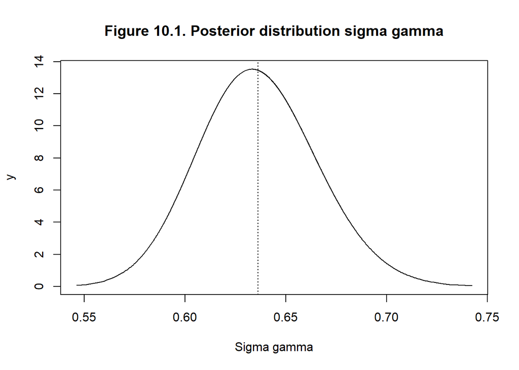

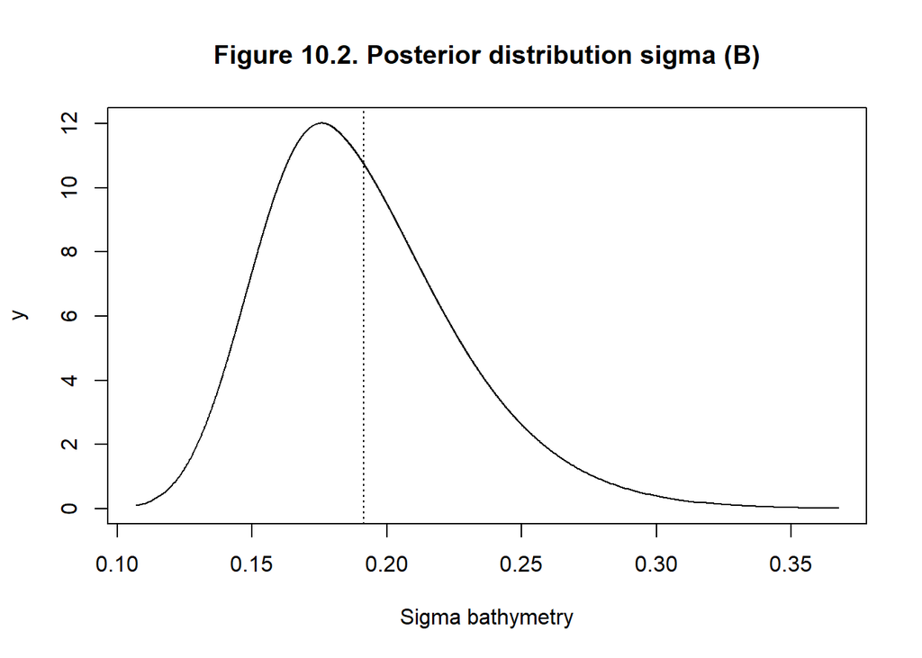

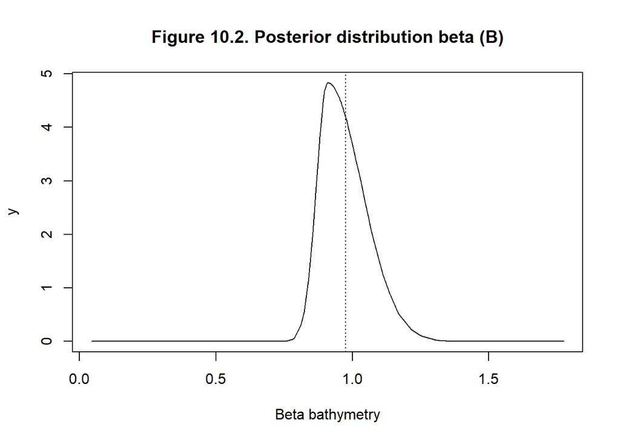

On the other hand, it is also possible to obtain the spatial term for each of the fitted processes (Bernuolli and Gamma). Figure 11 shows the results obtained for the spatial term.

### Figure 11.1

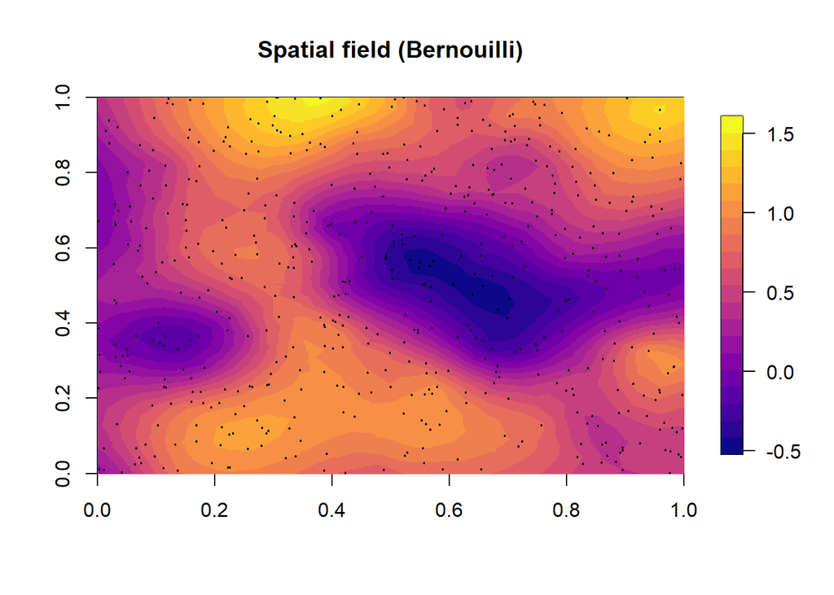

### Figure 11.2

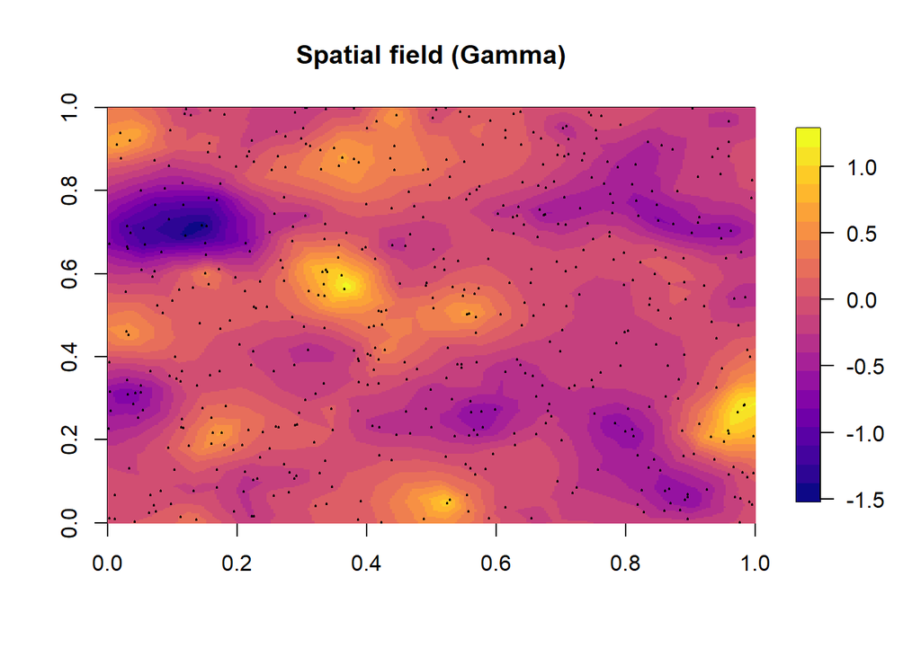

## Output smoothing

As a last output, the smoothing result for the bathymetry variable is shown (Figure 12). The smoothing pattern is practically the same as in the previous section.

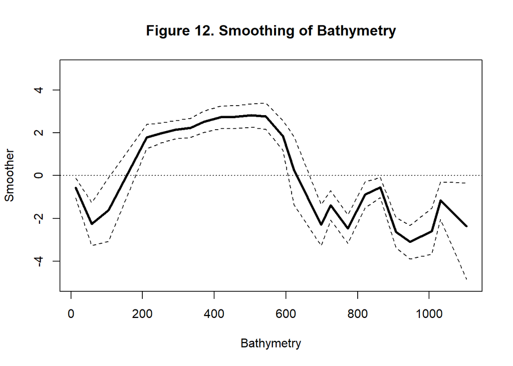

## Discussion

As a conclusion to the adjustment of the hurdle models, the result obtained has been much better than with the initial models, however, it seems that there are still unadjusted trends, so we could try to improve the model (adding more variables, etc.)

# Conclusions